# Risk Factor Analysis

## Outcome Variable

**Outcome Variable:** whz

## Predictor Variables

**Intervention Variable:** exclfeed36

**Adjustment Set:**

unadjusted

## Stratifying Variables

The analysis was stratified on these variable(s):

- agecat
- studyid
- country

## Data Summary

| agecat | studyid | country | exclfeed36 | n_cell | n |
| --- | --- | --- | --- | --- | --- |
| Birth | CMC-V-BCS-2002 | INDIA | 1 | 3 | 3 |
| Birth | CMC-V-BCS-2002 | INDIA | 0 | 0 | 3 |
| Birth | EE | PAKISTAN | 1 | 2 | 6 |
| Birth | EE | PAKISTAN | 0 | 4 | 6 |
| Birth | GMS-Nepal | NEPAL | 1 | 396 | 491 |
| Birth | GMS-Nepal | NEPAL | 0 | 95 | 491 |
| Birth | IRC | INDIA | 1 | 0 | 3 |
| Birth | IRC | INDIA | 0 | 3 | 3 |
| Birth | JiVitA-3 | BANGLADESH | 1 | 6736 | 8619 |
| Birth | JiVitA-3 | BANGLADESH | 0 | 1883 | 8619 |
| Birth | JiVitA-4 | BANGLADESH | 1 | 1711 | 2128 |
| Birth | JiVitA-4 | BANGLADESH | 0 | 417 | 2128 |
| Birth | Keneba | GAMBIA | 1 | 343 | 1192 |
| Birth | Keneba | GAMBIA | 0 | 849 | 1192 |
| Birth | MAL-ED | BANGLADESH | 1 | 31 | 208 |
| Birth | MAL-ED | BANGLADESH | 0 | 177 | 208 |
| Birth | MAL-ED | BRAZIL | 1 | 4 | 62 |
| Birth | MAL-ED | BRAZIL | 0 | 58 | 62 |
| Birth | MAL-ED | INDIA | 1 | 1 | 40 |
| Birth | MAL-ED | INDIA | 0 | 39 | 40 |
| Birth | MAL-ED | NEPAL | 1 | 0 | 25 |
| Birth | MAL-ED | NEPAL | 0 | 25 | 25 |
| Birth | MAL-ED | PERU | 1 | 5 | 218 |
| Birth | MAL-ED | PERU | 0 | 213 | 218 |
| Birth | MAL-ED | SOUTH AFRICA | 1 | 1 | 104 |
| Birth | MAL-ED | SOUTH AFRICA | 0 | 103 | 104 |
| Birth | MAL-ED | TANZANIA, UNITED REPUBLIC OF | 1 | 0 | 111 |
| Birth | MAL-ED | TANZANIA, UNITED REPUBLIC OF | 0 | 111 | 111 |
| Birth | PROVIDE | BANGLADESH | 1 | 115 | 483 |
| Birth | PROVIDE | BANGLADESH | 0 | 368 | 483 |

[output cut: 66 more lines]

The following strata were considered:

- agecat: 24 months, studyid: CMC-V-BCS-2002, country: INDIA
- agecat: 24 months, studyid: EE, country: PAKISTAN
- agecat: 24 months, studyid: GMS-Nepal, country: NEPAL
- agecat: 24 months, studyid: IRC, country: INDIA
- agecat: 24 months, studyid: JiVitA-3, country: BANGLADESH
- agecat: 24 months, studyid: JiVitA-4, country: BANGLADESH
- agecat: 24 months, studyid: Keneba, country: GAMBIA
- agecat: 24 months, studyid: LCNI-5, country: MALAWI
- agecat: 24 months, studyid: MAL-ED, country: BANGLADESH
- agecat: 24 months, studyid: MAL-ED, country: BRAZIL
- agecat: 24 months, studyid: MAL-ED, country: INDIA
- agecat: 24 months, studyid: MAL-ED, country: NEPAL
- agecat: 24 months, studyid: MAL-ED, country: PERU
- agecat: 24 months, studyid: MAL-ED, country: SOUTH AFRICA
- agecat: 24 months, studyid: MAL-ED, country: TANZANIA, UNITED REPUBLIC OF
- agecat: 24 months, studyid: PROVIDE, country: BANGLADESH
- agecat: 6 months, studyid: CMC-V-BCS-2002, country: INDIA
- agecat: 6 months, studyid: EE, country: PAKISTAN
- agecat: 6 months, studyid: GMS-Nepal, country: NEPAL
- agecat: 6 months, studyid: IRC, country: INDIA
- agecat: 6 months, studyid: JiVitA-3, country: BANGLADESH
- agecat: 6 months, studyid: JiVitA-4, country: BANGLADESH
- agecat: 6 months, studyid: Keneba, country: GAMBIA
- agecat: 6 months, studyid: LCNI-5, country: MALAWI
- agecat: 6 months, studyid: MAL-ED, country: BANGLADESH
- agecat: 6 months, studyid: MAL-ED, country: BRAZIL
- agecat: 6 months, studyid: MAL-ED, country: INDIA
- agecat: 6 months, studyid: MAL-ED, country: NEPAL
- agecat: 6 months, studyid: MAL-ED, country: PERU
- agecat: 6 months, studyid: MAL-ED, country: SOUTH AFRICA
- agecat: 6 months, studyid: MAL-ED, country: TANZANIA, UNITED REPUBLIC OF
- agecat: 6 months, studyid: PROVIDE, country: BANGLADESH
- agecat: 6 months, studyid: SAS-FoodSuppl, country: INDIA
- agecat: Birth, studyid: CMC-V-BCS-2002, country: INDIA
- agecat: Birth, studyid: EE, country: PAKISTAN
- agecat: Birth, studyid: GMS-Nepal, country: NEPAL
- agecat: Birth, studyid: IRC, country: INDIA
- agecat: Birth, studyid: JiVitA-3, country: BANGLADESH
- agecat: Birth, studyid: JiVitA-4, country: BANGLADESH
- agecat: Birth, studyid: Keneba, country: GAMBIA
- agecat: Birth, studyid: MAL-ED, country: BANGLADESH
- agecat: Birth, studyid: MAL-ED, country: BRAZIL
- agecat: Birth, studyid: MAL-ED, country: INDIA
- agecat: Birth, studyid: MAL-ED, country: NEPAL
- agecat: Birth, studyid: MAL-ED, country: PERU
- agecat: Birth, studyid: MAL-ED, country: SOUTH AFRICA
- agecat: Birth, studyid: MAL-ED, country: TANZANIA, UNITED REPUBLIC OF
- agecat: Birth, studyid: PROVIDE, country: BANGLADESH

### Dropped Strata

Some strata were dropped due to rare outcomes:

- agecat: Birth, studyid: CMC-V-BCS-2002, country: INDIA
- agecat: Birth, studyid: EE, country: PAKISTAN
- agecat: Birth, studyid: IRC, country: INDIA
- agecat: Birth, studyid: MAL-ED, country: BRAZIL
- agecat: Birth, studyid: MAL-ED, country: INDIA
- agecat: Birth, studyid: MAL-ED, country: NEPAL
- agecat: Birth, studyid: MAL-ED, country: SOUTH AFRICA
- agecat: Birth, studyid: MAL-ED, country: TANZANIA, UNITED REPUBLIC OF
- agecat: 6 months, studyid: CMC-V-BCS-2002, country: INDIA
- agecat: 6 months, studyid: EE, country: PAKISTAN
- agecat: 6 months, studyid: IRC, country: INDIA
- agecat: 6 months, studyid: MAL-ED, country: NEPAL
- agecat: 6 months, studyid: MAL-ED, country: SOUTH AFRICA
- agecat: 6 months, studyid: MAL-ED, country: TANZANIA, UNITED REPUBLIC OF
- agecat: 6 months, studyid: SAS-FoodSuppl, country: INDIA
- agecat: 24 months, studyid: CMC-V-BCS-2002, country: INDIA
- agecat: 24 months, studyid: EE, country: PAKISTAN
- agecat: 24 months, studyid: IRC, country: INDIA
- agecat: 24 months, studyid: MAL-ED, country: NEPAL
- agecat: 24 months, studyid: MAL-ED, country: PERU
- agecat: 24 months, studyid: MAL-ED, country: SOUTH AFRICA
- agecat: 24 months, studyid: MAL-ED, country: TANZANIA, UNITED REPUBLIC OF

## Methods Detail

We’re interested in the causal parameters $E[Y_a]$ for all values of $a \in \mathcal{A}$. These parameters represent the mean outcome if, possibly contrary to fact, we intervened to set all units to have $A=a$. Under the randomization and positivity assumptions, these are identified by the statistical parameters $\psi_a=E_W[E_{Y|A,W}(Y|A=a,W)]$. In addition, we’re interested in the mean of $Y$, $E[Y]$ under no intervention (the observed mean). We will estimate these parameters by using SuperLearner to fit the relevant likelihood factors – $E_{Y|A,W}(Y|A=a,W)$ and $p(A=a|W)$, and then updating our likelihood fit using a joint TMLE.

For unadjusted analyses ($W=\{\}$), initial likelihoods were estimated using Lrnr_glm to estimate the simple $E(Y|A)$ and Lrnr_mean to estimate $p(A)$. For adjusted analyses, a small library containing Lrnr_glmnet, Lrnr_xgboost, and Lrnr_mean was used.

Having estimated these parameters, we will then use the delta method to estimate relative risks and attributable risks relative to a prespecified baseline level of $A$.

# Results Detail

## Results Plots

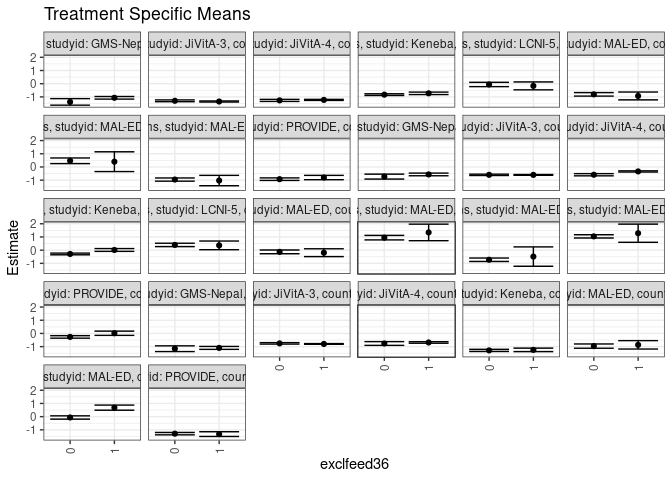

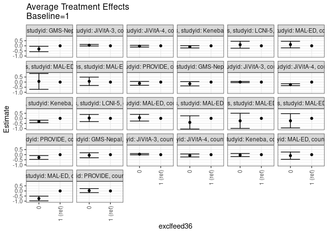

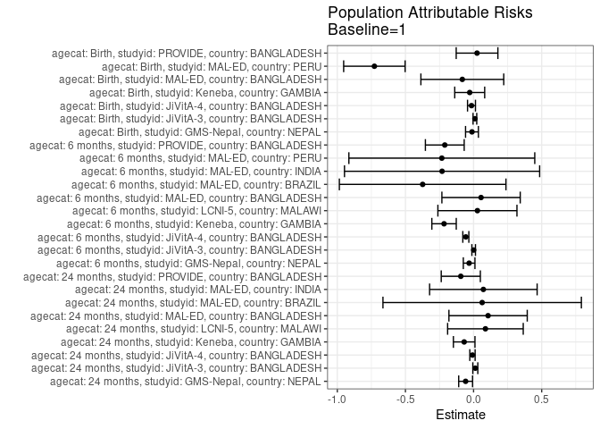

## Results Table

### Parameter: TSM

| agecat | studyid | country | intervention_level | baseline_level | estimate | ci_lower | ci_upper |
| --- | --- | --- | --- | --- | --- | --- | --- |
| Birth | GMS-Nepal | NEPAL | 1 | NA | -1.0968939 | -1.2083862 | -0.9854017 |
| Birth | GMS-Nepal | NEPAL | 0 | NA | -1.1572632 | -1.3736690 | -0.9408573 |
| Birth | JiVitA-3 | BANGLADESH | 1 | NA | -0.7989757 | -0.8263636 | -0.7715877 |
| Birth | JiVitA-3 | BANGLADESH | 0 | NA | -0.7543707 | -0.8087407 | -0.7000007 |
| Birth | JiVitA-4 | BANGLADESH | 1 | NA | -0.6866920 | -0.7433051 | -0.6300789 |
| Birth | JiVitA-4 | BANGLADESH | 0 | NA | -0.7642926 | -0.9045826 | -0.6240025 |
| Birth | Keneba | GAMBIA | 1 | NA | -1.2469679 | -1.3782137 | -1.1157222 |
| Birth | Keneba | GAMBIA | 0 | NA | -1.2866961 | -1.3677885 | -1.2056037 |
| Birth | MAL-ED | BANGLADESH | 1 | NA | -0.8654839 | -1.1841240 | -0.5468437 |
| Birth | MAL-ED | BANGLADESH | 0 | NA | -0.9625424 | -1.1239614 | -0.8011234 |
| Birth | MAL-ED | PERU | 1 | NA | 0.6820000 | 0.4886003 | 0.8753997 |
| Birth | MAL-ED | PERU | 0 | NA | -0.0629108 | -0.1888962 | 0.0630746 |
| Birth | PROVIDE | BANGLADESH | 1 | NA | -1.3221739 | -1.5016955 | -1.1426523 |
| Birth | PROVIDE | BANGLADESH | 0 | NA | -1.2887228 | -1.3786138 | -1.1988319 |
| 6 months | GMS-Nepal | NEPAL | 1 | NA | -0.5675000 | -0.6681819 | -0.4668181 |
| 6 months | GMS-Nepal | NEPAL | 0 | NA | -0.7311587 | -0.9180935 | -0.5442240 |
| 6 months | JiVitA-3 | BANGLADESH | 1 | NA | -0.6002660 | -0.6297120 | -0.5708199 |
| 6 months | JiVitA-3 | BANGLADESH | 0 | NA | -0.5970415 | -0.6465451 | -0.5475380 |
| 6 months | JiVitA-4 | BANGLADESH | 1 | NA | -0.3391867 | -0.3848399 | -0.2935336 |
| 6 months | JiVitA-4 | BANGLADESH | 0 | NA | -0.5901793 | -0.6726722 | -0.5076865 |
| 6 months | Keneba | GAMBIA | 1 | NA | 0.0156545 | -0.0913464 | 0.1226554 |
| 6 months | Keneba | GAMBIA | 0 | NA | -0.2865396 | -0.3504625 | -0.2226166 |
| 6 months | LCNI-5 | MALAWI | 1 | NA | 0.3642553 | 0.0371861 | 0.6913246 |
| 6 months | LCNI-5 | MALAWI | 0 | NA | 0.3984000 | 0.2718569 | 0.5249431 |
| 6 months | MAL-ED | BANGLADESH | 1 | NA | -0.1904444 | -0.4869579 | 0.1060690 |
| 6 months | MAL-ED | BANGLADESH | 0 | NA | -0.1276032 | -0.2690838 | 0.0138775 |
| 6 months | MAL-ED | BRAZIL | 1 | NA | 1.3456944 | 0.7198576 | 1.9715313 |
| 6 months | MAL-ED | BRAZIL | 0 | NA | 0.9493190 | 0.7797915 | 1.1188464 |
| 6 months | MAL-ED | INDIA | 1 | NA | -0.4850000 | -1.2185777 | 0.2485777 |
| 6 months | MAL-ED | INDIA | 0 | NA | -0.7254799 | -0.8547181 | -0.5962418 |
| 6 months | MAL-ED | PERU | 1 | NA | 1.2841667 | 0.5956438 | 1.9726896 |
| 6 months | MAL-ED | PERU | 0 | NA | 1.0459085 | 0.9221243 | 1.1696927 |
| 6 months | PROVIDE | BANGLADESH | 1 | NA | 0.0121034 | -0.1488055 | 0.1730124 |
| 6 months | PROVIDE | BANGLADESH | 0 | NA | -0.2659534 | -0.3613775 | -0.1705293 |
| 24 months | GMS-Nepal | NEPAL | 1 | NA | -1.0653085 | -1.1638986 | -0.9667184 |
| 24 months | GMS-Nepal | NEPAL | 0 | NA | -1.3779719 | -1.6245718 | -1.1313720 |
| 24 months | JiVitA-3 | BANGLADESH | 1 | NA | -1.3479946 | -1.3868366 | -1.3091525 |
| 24 months | JiVitA-3 | BANGLADESH | 0 | NA | -1.2931909 | -1.3612577 | -1.2251240 |
| 24 months | JiVitA-4 | BANGLADESH | 1 | NA | -1.2262676 | -1.2667777 | -1.1857574 |
| 24 months | JiVitA-4 | BANGLADESH | 0 | NA | -1.2626467 | -1.3409079 | -1.1843855 |
| 24 months | Keneba | GAMBIA | 1 | NA | -0.7284870 | -0.8231145 | -0.6338596 |
| 24 months | Keneba | GAMBIA | 0 | NA | -0.8274852 | -0.8904467 | -0.7645238 |
| 24 months | LCNI-5 | MALAWI | 1 | NA | -0.1641176 | -0.4633222 | 0.1350870 |
| 24 months | LCNI-5 | MALAWI | 0 | NA | -0.0573333 | -0.2194120 | 0.1047453 |
| 24 months | MAL-ED | BANGLADESH | 1 | NA | -0.9258000 | -1.2234413 | -0.6281587 |
| 24 months | MAL-ED | BANGLADESH | 0 | NA | -0.8050535 | -0.9373515 | -0.6727555 |
| 24 months | MAL-ED | BRAZIL | 1 | NA | 0.3995455 | -0.3492812 | 1.1483721 |
| 24 months | MAL-ED | BRAZIL | 0 | NA | 0.4670148 | 0.2530851 | 0.6809444 |
| 24 months | MAL-ED | INDIA | 1 | NA | -1.0300000 | -1.4230980 | -0.6369020 |
| 24 months | MAL-ED | INDIA | 0 | NA | -0.9551163 | -1.0754326 | -0.8348000 |
| 24 months | PROVIDE | BANGLADESH | 1 | NA | -0.8007801 | -0.9646126 | -0.6369477 |
| 24 months | PROVIDE | BANGLADESH | 0 | NA | -0.9248853 | -1.0207053 | -0.8290654 |

### Parameter: E(Y)

| agecat | studyid | country | intervention_level | baseline_level | estimate | ci_lower | ci_upper |
| --- | --- | --- | --- | --- | --- | --- | --- |
| Birth | GMS-Nepal | NEPAL | NA | NA | -1.1085743 | -1.2077878 | -1.0093609 |
| Birth | JiVitA-3 | BANGLADESH | NA | NA | -0.7892308 | -0.8133344 | -0.7651272 |
| Birth | JiVitA-4 | BANGLADESH | NA | NA | -0.7018985 | -0.7560164 | -0.6477806 |
| Birth | Keneba | GAMBIA | NA | NA | -1.2752643 | -1.3442810 | -1.2062476 |
| Birth | MAL-ED | BANGLADESH | NA | NA | -0.9480769 | -1.0934921 | -0.8026617 |
| Birth | MAL-ED | PERU | NA | NA | -0.0458257 | -0.1696487 | 0.0779973 |
| Birth | PROVIDE | BANGLADESH | NA | NA | -1.2966874 | -1.3774293 | -1.2159454 |
| 6 months | GMS-Nepal | NEPAL | NA | NA | -0.6001075 | -0.6890924 | -0.5111227 |
| 6 months | JiVitA-3 | BANGLADESH | NA | NA | -0.5995202 | -0.6251579 | -0.5738825 |
| 6 months | JiVitA-4 | BANGLADESH | NA | NA | -0.3960017 | -0.4356255 | -0.3563778 |
| 6 months | Keneba | GAMBIA | NA | NA | -0.2009461 | -0.2562412 | -0.1456509 |
| 6 months | LCNI-5 | MALAWI | NA | NA | 0.3925000 | 0.2735307 | 0.5114693 |
| 6 months | MAL-ED | BANGLADESH | NA | NA | -0.1354583 | -0.2647102 | -0.0062065 |
| 6 months | MAL-ED | BRAZIL | NA | NA | 0.9720774 | 0.8078144 | 1.1363403 |
| 6 months | MAL-ED | INDIA | NA | NA | -0.7161910 | -0.8437667 | -0.5886153 |
| 6 months | MAL-ED | PERU | NA | NA | 1.0511642 | 0.9291821 | 1.1731463 |
| 6 months | PROVIDE | BANGLADESH | NA | NA | -0.1990907 | -0.2817968 | -0.1163845 |
| 24 months | GMS-Nepal | NEPAL | NA | NA | -1.1236255 | -1.2167712 | -1.0304797 |
| 24 months | JiVitA-3 | BANGLADESH | NA | NA | -1.3352235 | -1.3688736 | -1.3015735 |
| 24 months | JiVitA-4 | BANGLADESH | NA | NA | -1.2344089 | -1.2708428 | -1.1979750 |
| 24 months | Keneba | GAMBIA | NA | NA | -0.7973955 | -0.8498696 | -0.7449213 |
| 24 months | LCNI-5 | MALAWI | NA | NA | -0.0770652 | -0.2204213 | 0.0662909 |
| 24 months | MAL-ED | BANGLADESH | NA | NA | -0.8192925 | -0.9412667 | -0.6973182 |
| 24 months | MAL-ED | BRAZIL | NA | NA | 0.4626233 | 0.2567495 | 0.6684971 |
| 24 months | MAL-ED | INDIA | NA | NA | -0.9581250 | -1.0746982 | -0.8415518 |
| 24 months | PROVIDE | BANGLADESH | NA | NA | -0.8945581 | -0.9774087 | -0.8117074 |

### Parameter: ATE

| agecat | studyid | country | intervention_level | baseline_level | estimate | ci_lower | ci_upper |
| --- | --- | --- | --- | --- | --- | --- | --- |
| Birth | GMS-Nepal | NEPAL | 1 | 1 | 0.0000000 | 0.0000000 | 0.0000000 |
| Birth | GMS-Nepal | NEPAL | 0 | 1 | -0.0603692 | -0.3038071 | 0.1830687 |
| Birth | JiVitA-3 | BANGLADESH | 1 | 1 | 0.0000000 | 0.0000000 | 0.0000000 |
| Birth | JiVitA-3 | BANGLADESH | 0 | 1 | 0.0446050 | -0.0171091 | 0.1063190 |
| Birth | JiVitA-4 | BANGLADESH | 1 | 1 | 0.0000000 | 0.0000000 | 0.0000000 |
| Birth | JiVitA-4 | BANGLADESH | 0 | 1 | -0.0776006 | -0.2265492 | 0.0713480 |
| Birth | Keneba | GAMBIA | 1 | 1 | 0.0000000 | 0.0000000 | 0.0000000 |
| Birth | Keneba | GAMBIA | 0 | 1 | -0.0397282 | -0.1940053 | 0.1145489 |
| Birth | MAL-ED | BANGLADESH | 1 | 1 | 0.0000000 | 0.0000000 | 0.0000000 |
| Birth | MAL-ED | BANGLADESH | 0 | 1 | -0.0970585 | -0.4542526 | 0.2601356 |
| Birth | MAL-ED | PERU | 1 | 1 | 0.0000000 | 0.0000000 | 0.0000000 |
| Birth | MAL-ED | PERU | 0 | 1 | -0.7449108 | -0.9757262 | -0.5140954 |
| Birth | PROVIDE | BANGLADESH | 1 | 1 | 0.0000000 | 0.0000000 | 0.0000000 |
| Birth | PROVIDE | BANGLADESH | 0 | 1 | 0.0334511 | -0.1673184 | 0.2342206 |
| 6 months | GMS-Nepal | NEPAL | 1 | 1 | 0.0000000 | 0.0000000 | 0.0000000 |
| 6 months | GMS-Nepal | NEPAL | 0 | 1 | -0.1636587 | -0.3759826 | 0.0486652 |
| 6 months | JiVitA-3 | BANGLADESH | 1 | 1 | 0.0000000 | 0.0000000 | 0.0000000 |
| 6 months | JiVitA-3 | BANGLADESH | 0 | 1 | 0.0032244 | -0.0537037 | 0.0601525 |
| 6 months | JiVitA-4 | BANGLADESH | 1 | 1 | 0.0000000 | 0.0000000 | 0.0000000 |
| 6 months | JiVitA-4 | BANGLADESH | 0 | 1 | -0.2509926 | -0.3459931 | -0.1559921 |
| 6 months | Keneba | GAMBIA | 1 | 1 | 0.0000000 | 0.0000000 | 0.0000000 |
| 6 months | Keneba | GAMBIA | 0 | 1 | -0.3021941 | -0.4268349 | -0.1775533 |
| 6 months | LCNI-5 | MALAWI | 1 | 1 | 0.0000000 | 0.0000000 | 0.0000000 |
| 6 months | LCNI-5 | MALAWI | 0 | 1 | 0.0341447 | -0.3165510 | 0.3848404 |
| 6 months | MAL-ED | BANGLADESH | 1 | 1 | 0.0000000 | 0.0000000 | 0.0000000 |
| 6 months | MAL-ED | BANGLADESH | 0 | 1 | 0.0628413 | -0.2656964 | 0.3913790 |
| 6 months | MAL-ED | BRAZIL | 1 | 1 | 0.0000000 | 0.0000000 | 0.0000000 |
| 6 months | MAL-ED | BRAZIL | 0 | 1 | -0.3963755 | -1.0447668 | 0.2520158 |
| 6 months | MAL-ED | INDIA | 1 | 1 | 0.0000000 | 0.0000000 | 0.0000000 |
| 6 months | MAL-ED | INDIA | 0 | 1 | -0.2404799 | -0.9853549 | 0.5043950 |
| 6 months | MAL-ED | PERU | 1 | 1 | 0.0000000 | 0.0000000 | 0.0000000 |
| 6 months | MAL-ED | PERU | 0 | 1 | -0.2382581 | -0.9378196 | 0.4613034 |
| 6 months | PROVIDE | BANGLADESH | 1 | 1 | 0.0000000 | 0.0000000 | 0.0000000 |
| 6 months | PROVIDE | BANGLADESH | 0 | 1 | -0.2780569 | -0.4651329 | -0.0909809 |
| 24 months | GMS-Nepal | NEPAL | 1 | 1 | 0.0000000 | 0.0000000 | 0.0000000 |
| 24 months | GMS-Nepal | NEPAL | 0 | 1 | -0.3126634 | -0.5782411 | -0.0470857 |
| 24 months | JiVitA-3 | BANGLADESH | 1 | 1 | 0.0000000 | 0.0000000 | 0.0000000 |
| 24 months | JiVitA-3 | BANGLADESH | 0 | 1 | 0.0548037 | -0.0237151 | 0.1333225 |
| 24 months | JiVitA-4 | BANGLADESH | 1 | 1 | 0.0000000 | 0.0000000 | 0.0000000 |
| 24 months | JiVitA-4 | BANGLADESH | 0 | 1 | -0.0363792 | -0.1234927 | 0.0507344 |
| 24 months | Keneba | GAMBIA | 1 | 1 | 0.0000000 | 0.0000000 | 0.0000000 |
| 24 months | Keneba | GAMBIA | 0 | 1 | -0.0989982 | -0.2126578 | 0.0146614 |
| 24 months | LCNI-5 | MALAWI | 1 | 1 | 0.0000000 | 0.0000000 | 0.0000000 |
| 24 months | LCNI-5 | MALAWI | 0 | 1 | 0.1067843 | -0.2334992 | 0.4470678 |
| 24 months | MAL-ED | BANGLADESH | 1 | 1 | 0.0000000 | 0.0000000 | 0.0000000 |
| 24 months | MAL-ED | BANGLADESH | 0 | 1 | 0.1207465 | -0.2049728 | 0.4464659 |
| 24 months | MAL-ED | BRAZIL | 1 | 1 | 0.0000000 | 0.0000000 | 0.0000000 |
| 24 months | MAL-ED | BRAZIL | 0 | 1 | 0.0674693 | -0.7113165 | 0.8462551 |
| 24 months | MAL-ED | INDIA | 1 | 1 | 0.0000000 | 0.0000000 | 0.0000000 |
| 24 months | MAL-ED | INDIA | 0 | 1 | 0.0748837 | -0.3362149 | 0.4859823 |
| 24 months | PROVIDE | BANGLADESH | 1 | 1 | 0.0000000 | 0.0000000 | 0.0000000 |
| 24 months | PROVIDE | BANGLADESH | 0 | 1 | -0.1241052 | -0.3139012 | 0.0656908 |

### Parameter: PAR

| agecat | studyid | country | intervention_level | baseline_level | estimate | ci_lower | ci_upper |
| --- | --- | --- | --- | --- | --- | --- | --- |
| Birth | GMS-Nepal | NEPAL | 1 | NA | -0.0116804 | -0.0588287 | 0.0354679 |
| Birth | JiVitA-3 | BANGLADESH | 1 | NA | 0.0097449 | -0.0037801 | 0.0232699 |
| Birth | JiVitA-4 | BANGLADESH | 1 | NA | -0.0152065 | -0.0443165 | 0.0139035 |
| Birth | Keneba | GAMBIA | 1 | NA | -0.0282963 | -0.1381847 | 0.0815920 |
| Birth | MAL-ED | BANGLADESH | 1 | NA | -0.0825931 | -0.3865880 | 0.2214019 |
| Birth | MAL-ED | PERU | 1 | NA | -0.7278257 | -0.9533592 | -0.5022921 |
| Birth | PROVIDE | BANGLADESH | 1 | NA | 0.0254865 | -0.1274860 | 0.1784591 |
| 6 months | GMS-Nepal | NEPAL | 1 | NA | -0.0326075 | -0.0752784 | 0.0100634 |
| 6 months | JiVitA-3 | BANGLADESH | 1 | NA | 0.0007458 | -0.0124224 | 0.0139139 |
| 6 months | JiVitA-4 | BANGLADESH | 1 | NA | -0.0568149 | -0.0789231 | -0.0347068 |
| 6 months | Keneba | GAMBIA | 1 | NA | -0.2166006 | -0.3061606 | -0.1270405 |
| 6 months | LCNI-5 | MALAWI | 1 | NA | 0.0282447 | -0.2618569 | 0.3183463 |
| 6 months | MAL-ED | BANGLADESH | 1 | NA | 0.0549861 | -0.2324965 | 0.3424687 |
| 6 months | MAL-ED | BRAZIL | 1 | NA | -0.3736171 | -0.9849087 | 0.2376745 |
| 6 months | MAL-ED | INDIA | 1 | NA | -0.2311910 | -0.9473188 | 0.4849368 |
| 6 months | MAL-ED | PERU | 1 | NA | -0.2330025 | -0.9150876 | 0.4490827 |
| 6 months | PROVIDE | BANGLADESH | 1 | NA | -0.2111941 | -0.3536017 | -0.0687865 |
| 24 months | GMS-Nepal | NEPAL | 1 | NA | -0.0583170 | -0.1091306 | -0.0075034 |
| 24 months | JiVitA-3 | BANGLADESH | 1 | NA | 0.0127710 | -0.0055113 | 0.0310534 |
| 24 months | JiVitA-4 | BANGLADESH | 1 | NA | -0.0081414 | -0.0276668 | 0.0113841 |
| 24 months | Keneba | GAMBIA | 1 | NA | -0.0689084 | -0.1480581 | 0.0102413 |
| 24 months | LCNI-5 | MALAWI | 1 | NA | 0.0870524 | -0.1904176 | 0.3645225 |
| 24 months | MAL-ED | BANGLADESH | 1 | NA | 0.1065075 | -0.1808495 | 0.3938646 |
| 24 months | MAL-ED | BRAZIL | 1 | NA | 0.0630778 | -0.6650221 | 0.7911777 |
| 24 months | MAL-ED | INDIA | 1 | NA | 0.0718750 | -0.3227110 | 0.4664610 |
| 24 months | PROVIDE | BANGLADESH | 1 | NA | -0.0937779 | -0.2372601 | 0.0497042 |